# 3.5.1 - Advanced - Geospatial Analysis

advanced

geospatial

vector

R

hedonic

pricing

shapefile

CRS

This notebook introduces geospatial analysis with vector data in R. We go over basic geospatial objects and operations.

Published

24 June 2024

## Outline

### Prerequisites

- Intermediate R skills
- Theoretical understanding of multiple regression
- Basic geometry

### Outcomes

After completing this notebook, you will be able to:

- Manipulate geospatial objects in R using the `sf` package
- Perform geospatial operations on real world data
- Understand applications of geospatial analysis in the context of economic research

### References

- [Geocomputation with R](https://r.geocompx.org/intro)

## Introduction

In this notebook, we’ll introduce the basics of geospatial analysis with vector data. We’ll use the `sf` package and data from `spData` for our examples.

```r
# load packages
library(tidyverse)
library(ggplot2)
library(sandwich)
library(lmtest)
library(sf)
library(spData)

# load self-tests
source('advanced_geospatial_tests.r')
```

## Part 1: Geospatial Data

Geospatial data is data coded to represent physical objects. For example, let’s say we’re interested in analyzing the accessibility of healthcare in BC. A dataset containing locations of emergency departments (coded in longitude and latitude coordinates) and population density per municipality would constitute a geospatial dataset. We could use the geospatial data to estimate the share of BC residents within 10km of an emergency department. That analysis would involve calculating relationships between physical objects (i.e., location of emergency departments) and overlaying numeric data (i.e., population density per municipality) on the physical objects.

The first step to learning how to conduct geospatial analyses like this in R is to understand how geospatial data is stored - that’s what we’ll cover in this section.

### Vector vs Raster Data

In R, geospatial data can be stored as either **vector data** or **raster data**.

- **Vector data** is coded in a collection of mathematical objects, such as points, lines, and polygons. Geospatial objects with vector data have discrete boundaries and are associated with specific locations through a **coordinate reference systems (CRS)**.
- **Raster data** is coded as 2-D cells with constant size, called pixels. These pixels are accompanied with information that links them with a specific location.

Vector data is most widely used in the social sciences because applications in politics or economics typically require discrete boundaries of administrative regions (e.g., country or state borders). For this reason, we’ll focus on conducting geospatial analysis with vector data.

Vector data codes geospatial objects with the following elements:

- **Points**, coded as `c(x, y)`: the most basic element, used when the area of the objects are not meaningful (e.g., locations of emergency departments in BC).
- **Linestrings**, coded as `rbind(c(x1, y1), c(x2, y2), c(x3, y3))`: a series of points, used when the length of an object is meaningful but the area is not (e.g., rivers, roads).
- **Polygons**, coded as `list(rbind(c(x1, y1), c(x2, y2), c(x3, y3), c(x1, y1)))`: a series of *closed* points, used when the area of an object is meaningful (e.g., Canadian provinces, metropolitan areas, protected areas).

> **Note**: to be closed objects, polygons need to start and end at the same points; notice above that the polygon starts at `c(x1, y1)` and also ends at `c(x1, y1)`.

What exactly are these (x, y) coordinates? How does R (and the user) know which locations these coordinates represent?

### Coordinate Reference Systems

A coordinate reference system can be thought of as the base map in which your geospatial objects will be overlayed. There are two main types of CRS for vector data: **geographic CRS** and **projected CRS**.

- **Geographic CRS** map locations with longitude and latitude coordinates. The x’s and y’s for the points, linestrings, and polygons introduced above will simply be longitude and latitude coordinates on the base map.

> **Note**: Geographic coordinates are spherical! This means that you cannot use the distance formula you learned in high-school to calculate the distance between two points coded in `c(longitude, latitude)` format. More on this later.
- **Projected CRS** map locations with Cartesian coordinates on a flat surface. The x’s and y’s for the points, linestrings, and polygons introduced above will simply be x’s and y’s of a regular xy plane grid. There are different ways to project the earth on a flat surface, and that implies different ways to store objects and the relationships between them (e.g., conic, cylindrical, equidistant, equal-area…). More on this later.

### The `sf` package

The `sf` package is currently the most widely used package for manipulating geospatial data in vector format in R. The package supports all of the elements described above (i.e., points, linestrings, polygons), as well as any combination of those objects (i.e., multipoints, multilinestrings, multipolygons, and geometry collections). We’ll introduce them as needed throughout this notebook.

The beauty of the `sf` package is that it is compatible with `tidyverse`: geometric objects are stored in dataframes, and we can manipulate those objects with the typical `tidyverse` functions we use with non-spatial datasets.

To illustrate, let’s create some geospatial data from scratch.

```r
# creating a point
a_point <- c(0,1)
class(a_point)
```

```
[1] "numeric"
```

Let’s transform our point into a geospatial object using the `st_point()` function.

```r
# transforming point into geospatial object
geo_point <- st_point(a_point)
geo_point
```

```
POINT (0 1)
```

```r
class(geo_point)
```

```
[1] "XY"    "POINT" "sfg"
```

Notice that the data is coded as `POINT (0 1)` and the type of the object is `sfg`, which stands for **simple feature geometry**. The functions to transform R numeric vectors into `sfg` objects are:

- `st_point()`
- `st_linestring()`
- `st_polygon()`

We can bind these `sfg` objects into a simple feature column with the function `st_sfc()`.

```r
# creating two more points
another_point <- c(1,2)
yet_another_point <- c(3,3)

# transforming points into `sfg` objects
geo_point_2 <- st_point(another_point)
geo_point_3 <- st_point(yet_another_point)

# combining `sfg` objects into a simple feature column
sfc_obj <- st_sfc(geo_point, geo_point_2, geo_point_3)
class(sfc_obj)
```

```
[1] "sfc_POINT" "sfc"
```

Now the type of the object is `sfc`. R also recognizes that it is a `sfc_POINT`, because we only passed points to the simple features column. Simple feature columns support different types of simple feature objects in a same column (e.g., a column with a point, a linestring, and a geometry collection).

Since we have coded our elements as geospatial data, we can now plot the points in space.

```r
plot(sfc_obj)
```

[output not shown]

Let’s take a look at the output of `sfc_obj`.

```r
sfc_obj
```

```
Geometry set for 3 features
Geometry type: POINT
Dimension:     XY
Bounding box:  xmin: 0 ymin: 1 xmax: 3 ymax: 3
CRS:           NA
```

```
POINT (0 1)
```

```
POINT (1 2)
```

```
POINT (3 3)
```

The output of this object gives us the following information:

- We only have points as geometric objects in the column
- The dimension of our objects is 2-D (i.e., we only passed 2 coordinates for each point `c(x, y)`)
- The bounds of our plot are `[c(0,1), c(3,1), c(3,3), c(0,3)]`
- We have not specified a CRS (i.e., we don’t have a base map)

We can specify the CRS for our geometric data when creating the `sfc` object with the parameter `crs`. Here, we have chosen the `crs` “EPSG:4326”, which is a basic map of the world.

```r
sfc_obj_with_crs <- st_sfc(geo_point, geo_point_2, geo_point_3, crs = "EPSG:4326")
sfc_obj_with_crs
```

```
Geometry set for 3 features
Geometry type: POINT
Dimension:     XY
Bounding box:  xmin: 0 ymin: 1 xmax: 3 ymax: 3
Geodetic CRS:  WGS 84
```

```
POINT (0 1)
```

```
POINT (1 2)
```

```
POINT (3 3)
```

Once we specify the CRS, R knows which locations on Earth our geometric objects refer to. This allows us to overlay objects we create on existing geospatial objects that share the same CRS.

Let’s see this in practice. Let’s load the `world` dataset from the `spData` package. We’ll use this dataset, which contains country borders, to overlay two lines connecting Salvador, Brazil, to (1) Luanda, Angola, and to (2) Maputo, Mozambique.

```r
# check the data and plot the `world` geometry
head(world)
```

```
Simple feature collection with 6 features and 10 fields
Geometry type: MULTIPOLYGON
Dimension:     XY
Bounding box:  xmin: -180 ymin: -18.28799 xmax: 180 ymax: 83.23324
Geodetic CRS:  WGS 84
# A tibble: 6 × 11
  iso_a2 name_long  continent region_un subregion type  area_km2     pop lifeExp
  <chr>  <chr>      <chr>     <chr>     <chr>     <chr>    <dbl>   <dbl>   <dbl>
1 FJ     Fiji       Oceania   Oceania   Melanesia Sove…   1.93e4  8.86e5    70.0
2 TZ     Tanzania   Africa    Africa    Eastern … Sove…   9.33e5  5.22e7    64.2
3 EH     Western S… Africa    Africa    Northern… Inde…   9.63e4 NA         NA
4 CA     Canada     North Am… Americas  Northern… Sove…   1.00e7  3.55e7    82.0
5 US     United St… North Am… Americas  Northern… Coun…   9.51e6  3.19e8    78.8
6 KZ     Kazakhstan Asia      Asia      Central … Sove…   2.73e6  1.73e7    71.6
# ℹ 2 more variables: gdpPercap <dbl>, geom <MULTIPOLYGON [°]>
```

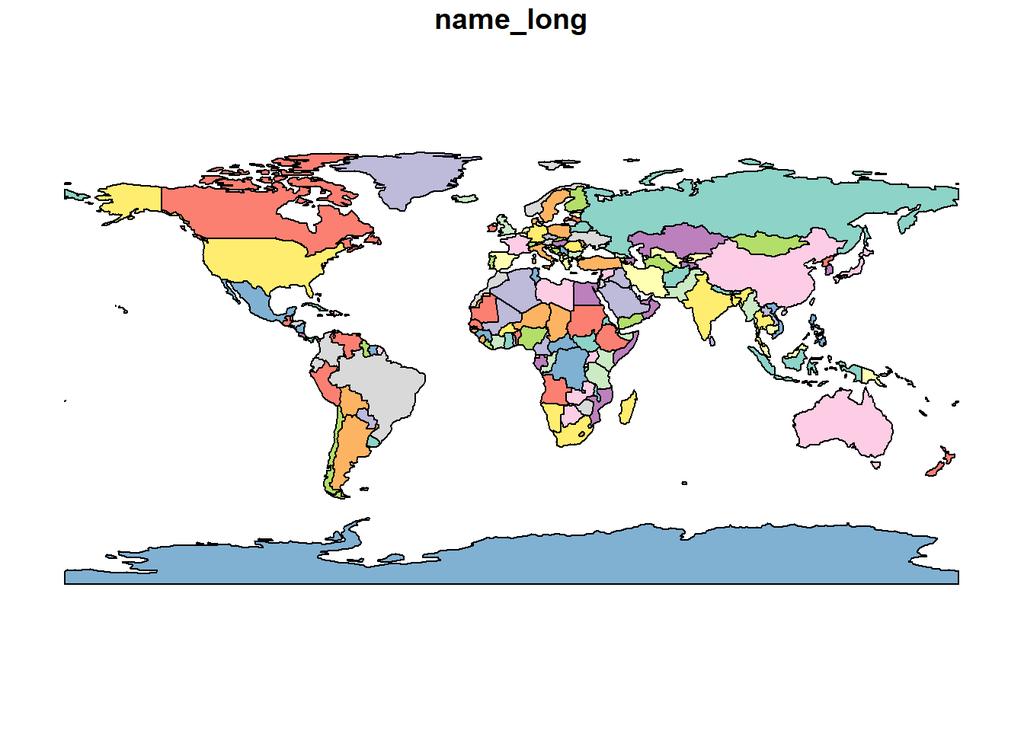

```r
plot(world["name_long"]) # specify that we want to plot the attribute `name_long`
```

We can see from the output above that the country boundaries are stored as multipolygons, and that the CRS for the `world` geometry is WGS 84.

As shown earlier, the argument used to transform numeric vectors to this CRS is `crs = "EPSG:4326"`. Let’s use that information to draw the lines from Salvador to Luanda and Maputo and overlay them on the plot. We’ll need the coordinates of these cities, which we can find by searching for them online.

> **Note**: for this CRS, we need to specify the coordinates as `c(longitude, latitude)`. The longitude and latitude of Salvador are approximately `c(-38.5, -13)` and those of Luanda and Maputo are `c(13.2, -8.8)` and `c(32.6, -26)` respectively.

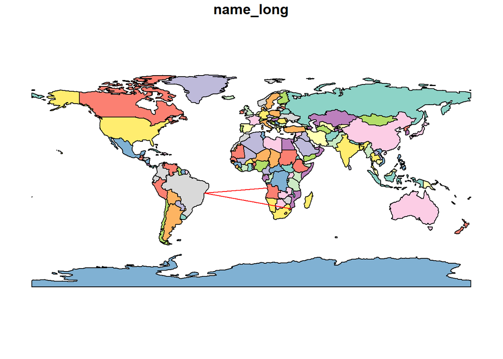

```r
# create lines with `st_linestring()`
line_luanda <- st_linestring(rbind(c(-38.5, -13), c(13.2, -8.8)))
line_maputo <- st_linestring(rbind(c(-38.5, -13), c(32.6, -26)))

# create simple feature column
lines_sfc <- st_sfc(line_luanda, line_maputo, crs = "EPSG:4326")

plot(world["name_long"], reset = FALSE)
plot(lines_sfc, add = TRUE, col ="red") # overlay the lines
```

The `plot()` function is the easiest way to plot geospatial objects in R. The default of this function plots one map for each attribute (try running `plot(world)` to see for yourself), so we specify `name_long` to plot a single map for the output. The parameters `reset = FALSE` and `add = TRUE` are needed to overlay plots.

### Geospatial Operations

We now turn our attention to objects that contain both simple features and other data types as columns. The `world` dataset, which we used in the previous section, has those features. Let’s examine this dataset further.

```r
str(world)
```

```
sf [177 × 11] (S3: sf/tbl_df/tbl/data.frame)
 $ iso_a2   : chr [1:177] "FJ" "TZ" "EH" "CA" ...
 $ name_long: chr [1:177] "Fiji" "Tanzania" "Western Sahara" "Canada" ...
 $ continent: chr [1:177] "Oceania" "Africa" "Africa" "North America" ...
 $ region_un: chr [1:177] "Oceania" "Africa" "Africa" "Americas" ...
 $ subregion: chr [1:177] "Melanesia" "Eastern Africa" "Northern Africa" "Northern America" ...
 $ type     : chr [1:177] "Sovereign country" "Sovereign country" "Indeterminate" "Sovereign country" ...
 $ area_km2 : num [1:177] 19290 932746 96271 10036043 9510744 ...
 $ pop      : num [1:177] 8.86e+05 5.22e+07 NA 3.55e+07 3.19e+08 ...
 $ lifeExp  : num [1:177] 70 64.2 NA 82 78.8 ...
 $ gdpPercap: num [1:177] 8222 2402 NA 43079 51922 ...
 $ geom     :sfc_MULTIPOLYGON of length 177; first list element: List of 3
  ..$ :List of 1
  .. ..$ : num [1:5, 1:2] -180 -180 -180 -180 -180 ...
  ..$ :List of 1
  .. ..$ : num [1:9, 1:2] 178 178 177 177 178 ...
  ..$ :List of 1
  .. ..$ : num [1:8, 1:2] 180 180 179 179 179 ...
  ..- attr(*, "class")= chr [1:3] "XY" "MULTIPOLYGON" "sfg"
 - attr(*, "sf_column")= chr "geom"
 - attr(*, "agr")= Factor w/ 3 levels "constant","aggregate",..: NA NA NA NA NA NA NA NA NA NA
  ..- attr(*, "names")= chr [1:10] "iso_a2" "name_long" "continent" "region_un" ...
```

```r
class(world)
```

```
[1] "sf"         "tbl_df"     "tbl"        "data.frame"
```

We can see that `world` contains the boundaries of countries as multipolygons, but also contains attributes of those countries as other types of data. Recognizing this, R categorizes this dataset as both `sf` and `data.frame`.

We can create `sf` objects with categorical and numeric attributes using the function `st_sf()`. Let’s show this by creating a custom dataset for three cities in Portugal.

```r
# create a data.frame object containing the cities and their populations
city_attr <- data.frame(
  name = c("Lisboa", "Coimbra", "Porto"),
  population = c(545796, 106655, 231800)
)

# specify points as c(lon, lat) coordinates of cities
l_coord <- st_point(c(-9.1, 38.7))
c_coord <- st_point(c(-8.4, 40.2))
p_coord <- st_point(c(-8.6, 41.1))

# create a column with the specified CRS
coordinates <- st_sfc(l_coord, c_coord, p_coord, crs = "EPSG:4326")

# create `sf` object with the data.frame and the sfc
city_data <- st_sf(city_attr, geometry = coordinates)
city_data
```

```
Simple feature collection with 3 features and 2 fields
Geometry type: POINT
Dimension:     XY
Bounding box:  xmin: -9.1 ymin: 38.7 xmax: -8.4 ymax: 41.1
Geodetic CRS:  WGS 84
     name population          geometry
1  Lisboa     545796 POINT (-9.1 38.7)
2 Coimbra     106655 POINT (-8.4 40.2)
3   Porto     231800 POINT (-8.6 41.1)
```

```r
class(city_data)
```

```
[1] "sf"         "data.frame"
```

The image below illustrates the process of creating `sf` objects from `sfc` and `data.frame` objects, which we did above.

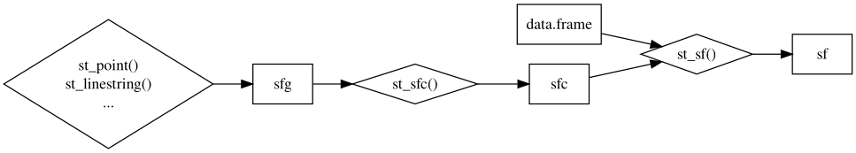

Lovelace, Robin and Nowosad, Jakub and Muenchow, Jannes, (2019). Geocomputation with R.

Now let’s suppose we want to merge `city_data` with data from the major rivers in Portugal that pass through those cities.

> **Note**: These are not the actual coordinates of the rivers. The points are simulated and made so that they pass through the major cities.

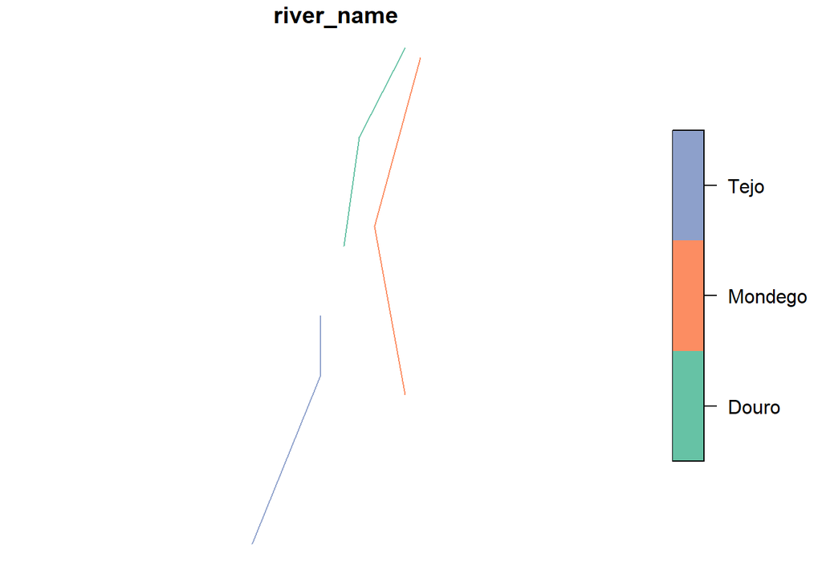

```r
# creating river data
# data.frame object
river_names = data.frame(
  river_name = c("Tejo", "Mondego", "Douro")
)

# specify points as c(lon, lat) coordinates of rivers
t_coord <- st_linestring(rbind(c(-10, 37), c(-9.1, 38.7), c(-9.1, 39.3)))
m_coord <- st_linestring(rbind(c(-8, 38.5), c(-8.4, 40.2), c(-7.8, 41.9)))
d_coord <- st_linestring(rbind(c(-8, 42),c(-8.6, 41.1), c(-8.8, 40)))

# create a column with the specified CRS
rivers <- st_sfc(t_coord, m_coord, d_coord, crs = "EPSG:4326")

# create `sf` object with the data.frame and the sfc
river_data <- st_sf(river_names, river_geometry = rivers)
plot(river_data)
```

One way of joining the data is to simply attach columns with `cbind()`.

```r
portugal_data <- cbind(city_data, river_data)
portugal_data
```

```
Simple feature collection with 3 features and 3 fields
Active geometry column: geometry
Geometry type: POINT
Dimension:     XY
Bounding box:  xmin: -9.1 ymin: 38.7 xmax: -8.4 ymax: 41.1
Geodetic CRS:  WGS 84
     name population river_name          geometry
1  Lisboa     545796       Tejo POINT (-9.1 38.7)
2 Coimbra     106655    Mondego POINT (-8.4 40.2)
3   Porto     231800      Douro POINT (-8.6 41.1)
                  river_geometry
1 LINESTRING (-10 37, -9.1 38...
2 LINESTRING (-8 38.5, -8.4 4...
3 LINESTRING (-8 42, -8.6 41....
```

Another way to join datasets is through geospatial operations. These operations allow us to filter, merge, or subset dataframes based on whether points, lines, and polygons touch, intersect, or contain other geospatial objects.

For example, let’s say we don’t know which river borders which city and we want to use geospatial operations to find out. We can use `st_join()` to merge both datasets based on intersections. `st_join()` is basically a left join in which the matches are determined by the relationships between the spatial objects.

```r
# merge city_data with river_data
pt_data <- st_join(city_data, river_data["river_name"])    # specify "river_name" to keep it in the merged dataset
pt_data
```

```
Simple feature collection with 3 features and 3 fields
Geometry type: POINT
Dimension:     XY
Bounding box:  xmin: -9.1 ymin: 38.7 xmax: -8.4 ymax: 41.1
Geodetic CRS:  WGS 84
     name population river_name          geometry
1  Lisboa     545796       Tejo POINT (-9.1 38.7)
2 Coimbra     106655    Mondego POINT (-8.4 40.2)
3   Porto     231800      Douro POINT (-8.6 41.1)
```

`st_join()` assigns the names of the rivers to the observations in which the point (i.e., city) intersects with the line (i.e., river).

> **Note**: `st_join()` drops the geometry of the second object.

Similar to `st_join()`, we can filter, merge, or subset `sf` objects with other geospatial functions. The most common types of geospatial operations are:

- `st_intersects()`
- `st_disjoin()`
- `st_contains()`
- `st_overlaps()`
- `st_within()`

You can learn more about the different geospatial operations in the [documentation of the package](https://r-spatial.github.io/sf/reference/st_join.html).

### Test your Knowledge

Create a polygon with vertices (0,0), (0,3), (3,6), (6,3), (6,0). Your answer must be a `sfg` object.

```r
polygon_1 <- st_...(...(...(...)))

answer_1 <- polygon_1

test_1()
```

Determine whether the following points are contained in the polygon with a geospatial operation.

```r
point_1 <- st_point(c(0,0))
point_2 <- st_point(c(3,4))
point_3 <- st_point(c(3,3))
point_4 <- st_point(c(4,5))
point_5 <- st_point(c(6,6))
points <- st_sfc(point_1, point_2, point_3, point_4, point_5)
```

> **Hint**: you only need to run one function.

```r
answer_2 <- st_...(...)

test_2()
```

> **Think Deeper**: once you get to the correct answer of question 2, inspect the output of `answer_2`. What does it mean? How is it different than the intersection of two objects?

Which of the following functions should be used to create an object with a simple feature column and other attributes?

1. `as_data_frame()`
2. `st_sfg()`
3. `st_sfc()`
4. `st_sf()`

```r
# Replace ... by your answer of "A", "B", "C" or "D"
answer_3 <- "..."

test_3()
```

What are the common coordinate inputs for geographic CRS?

1. `c(lat, lon)`
2. `c(lon, lat)`
3. `c(x, y)`
4. `c(y, x)`

```r
# Replace ... by your answer of "A", "B", "C" or "D"
answer_4 <- "..."

test_4()
```

## Part 2: Hedonic Pricing with Data from Athenian Properties

In this section, we’re going to estimate the value of apartment characteristics with a hedonic pricing function for apartments located in Athens, Greece. We’ll use the geospatial datasets `depmunic` and `properties` from the package `spData`.

### Theory

Typically, economists rely on market prices to estimate consumers’ marginal willingness to pay for a good. When the good in question is not traded in markets, economists must resort to other strategies. One of those strategies is the **hedonic pricing method**.

The main assumption of hedonic pricing is that *the total price of a good equals the sum of the prices of its components*. Using this assumption, we can deconstruct the price of a good traded in markets and attribute part of the total price to each of its non-traded component parts. For example, we can model the price of an apartment as a function of its size, view, age, location, number of bathrooms, proximity to public service, etc. If we take two apartments that are exactly equal but only differ on their view (e.g., one might be on the 2nd floor and the other on the 30th floor of the same building), their difference in price must be the added value of the view. If we have data on the prices and attributes of several apartments, we could leverage hedonic pricing to estimate how much consumers value a nice view.

> **Think Deeper**: what are the other underlying assumptions of hedonic pricing? When might it not be appropriate to use this method to value non-traded goods?

A model for the hedonic price of an apartment could be estimated with the following regression:

$$P_{i} = \beta_{0} + \beta_{1} Size_{i} + \beta_{2} Age_{i} + \beta_{3} Bath_{i} + \beta_{4} View_{i} + \beta_{5} Room_{i} + \beta_{6} Park_{i} + ... + \beta_{k} X_{ki}$$

where

- $P_{i}$ is the price per square meter of apartment $i$
- The variables $Size$, $Age$, $Bath$, $View$, $Room$, $Park$, $...$, $X_{k}$ are the components of the apartment
- The $\beta_{k}$s are the effects of those components on the price of the apartment

With that in mind, let’s try to estimate the hedonic pricing function of apartments in Athens.

### Exploratory Analysis

Let’s load two datasets from the `spData` package.

- `depmunic` has information on the 7 districts of the municipality of Athens. The district boundaries are stored in the data as polygons.
- `properties` has data on properties for sale in the city of Athens. Property locations are stored in the data as points.

Let’s start with `depmunic`.

```r
head(depmunic)
```

```
Simple feature collection with 6 features and 7 fields
Geometry type: POLYGON
Dimension:     XY
Bounding box:  xmin: 472365.2 ymin: 4199888 xmax: 479418.7 ymax: 4209186
Projected CRS: GGRS87 / Greek Grid
  num_dep airbnb museums population pop_rest  greensp     area
1       1   2171      17      72962     8202 433582.0 7.205019
2       2    721       1     102439     5009 478951.0 4.835935
3       3    524       0      45168     2735  43311.6 5.618766
4       4    144       0      84544     4167  40656.1 4.505970
5       5    231       0      98283     5099  41368.9 4.022963
6       6    565       0     129603    16531 154991.0 3.986820
                        geometry
1 POLYGON ((476647.7 4205011,...
2 POLYGON ((477524 4202889, 4...
3 POLYGON ((473380.8 4204841,...
4 POLYGON ((475574.7 4205608,...
5 POLYGON ((477087.2 4209179,...
6 POLYGON ((476992 4206457, 4...
```

```r
str(depmunic)
```

```
Classes 'sf' and 'data.frame':  7 obs. of  8 variables:
 $ num_dep   : int  1 2 3 4 5 6 7
 $ airbnb    : num  2171 721 524 144 231 ...
 $ museums   : num  17 1 0 0 0 0 0
 $ population: num  72962 102439 45168 84544 98283 ...
 $ pop_rest  : num  8202 5009 2735 4167 5099 ...
 $ greensp   : num  433582 478951 43312 40656 41369 ...
 $ area      : num  7.21 4.84 5.62 4.51 4.02 ...
 $ geometry  :sfc_POLYGON of length 7; first list element: List of 1
  ..$ : num [1:319, 1:2] 476648 476721 476725 476808 476822 ...
  ..- attr(*, "class")= chr [1:3] "XY" "POLYGON" "sfg"
 - attr(*, "sf_column")= chr "geometry"
 - attr(*, "agr")= Factor w/ 3 levels "constant","aggregate",..: NA NA NA NA NA NA NA
  ..- attr(*, "names")= chr [1:7] NA NA NA NA ...
```

We can see that the dataset has attributes of the districts: `airbnb`, `museums`, `population`, …

We can also see that the CRS used for this dataset is a Greek CRS: Projected CRS: GGRS87 / Greek Grid. This tells us that we’re dealing with a projected CRS tailored to Greece. A quick search will find that the units of reference are in meters.

> **Note**: a crucial part of geospatial data exploration is learning about the CRS of the dataset. This not only affects the relationships within your own dataset but also determines whether you can merge or filter geospatial objects based on other datasets.

Let’s plot the `depmunic` data. We specify the attribute greenspace `["greensp"]` to plot a chart of the green space exclusively.

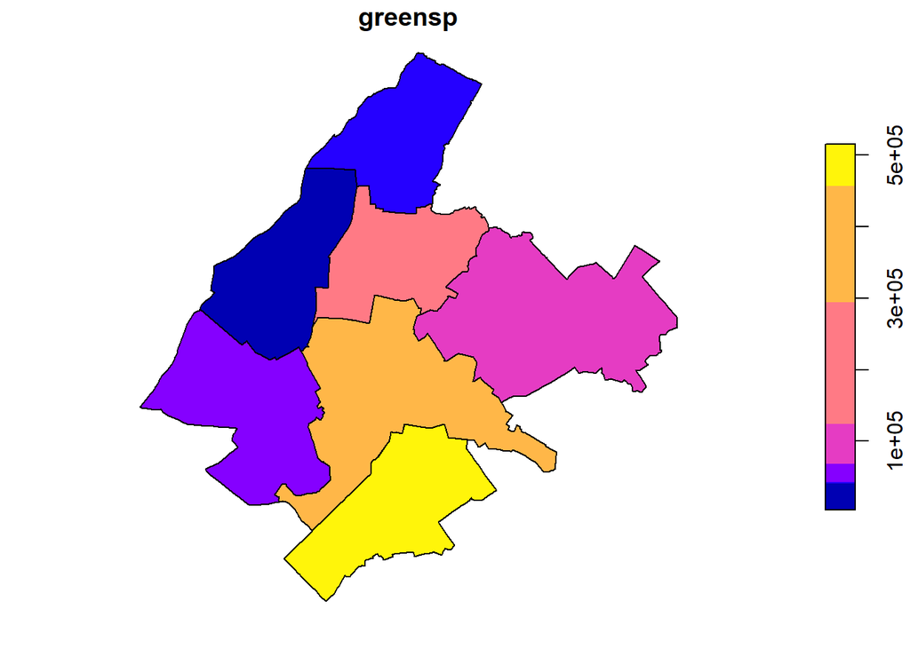

```r
plot(depmunic["greensp"])
```

Now let’s take a look at our `properties` data.

```r
head(properties)
```

```
Simple feature collection with 6 features and 6 fields
Geometry type: POINT
Dimension:     XY
Bounding box:  xmin: 475649.5 ymin: 4201115 xmax: 477290.7 ymax: 4207786
Projected CRS: GGRS87 / Greek Grid
       id size  price    prpsqm age dist_metro                 geometry
7836 7836   74  95000 1283.7838  47 623.874638 POINT (477144.1 4207786)
7238 7238   77 165000 2142.8571  10 509.471981 POINT (475649.5 4207224)
368   368   85  22000  258.8235  42 862.132569 POINT (477269.9 4201115)
938   938   85 225000 2647.0588  51   5.461505 POINT (476099.5 4202088)
6693 6693  102  50000  490.1961  37 312.350026 POINT (476260.6 4206307)
1953 1953  150 500000 3333.3333  37 485.829813 POINT (477290.7 4203248)
```

```r
str(properties)
```

```
Classes 'sf' and 'data.frame':  1000 obs. of  7 variables:
 $ id        : chr  "7836" "7238" "368" "938" ...
 $ size      : int  74 77 85 85 102 150 70 35 100 71 ...
 $ price     : int  95000 165000 22000 225000 50000 500000 105000 8500 160000 31000 ...
 $ prpsqm    : num  1284 2143 259 2647 490 ...
 $ age       : num  47 10 42 51 37 37 1 47 11 57 ...
 $ dist_metro: num  623.87 509.47 862.13 5.46 312.35 ...
 $ geometry  :sfc_POINT of length 1000; first list element:  'XY' num  477144 4207786
 - attr(*, "sf_column")= chr "geometry"
 - attr(*, "agr")= Factor w/ 3 levels "constant","aggregate",..: NA NA NA NA NA NA
  ..- attr(*, "names")= chr [1:6] "id" "size" "price" "prpsqm" ...
```

We can see that the dataset has attributes of the properties: `size`, `price`, `age`, …

We can see that the CRS used for this dataset is also the Greek CRS. This is good news: both our datasets are referenced to the same grid.

Let’s plot our `properties` dataset.

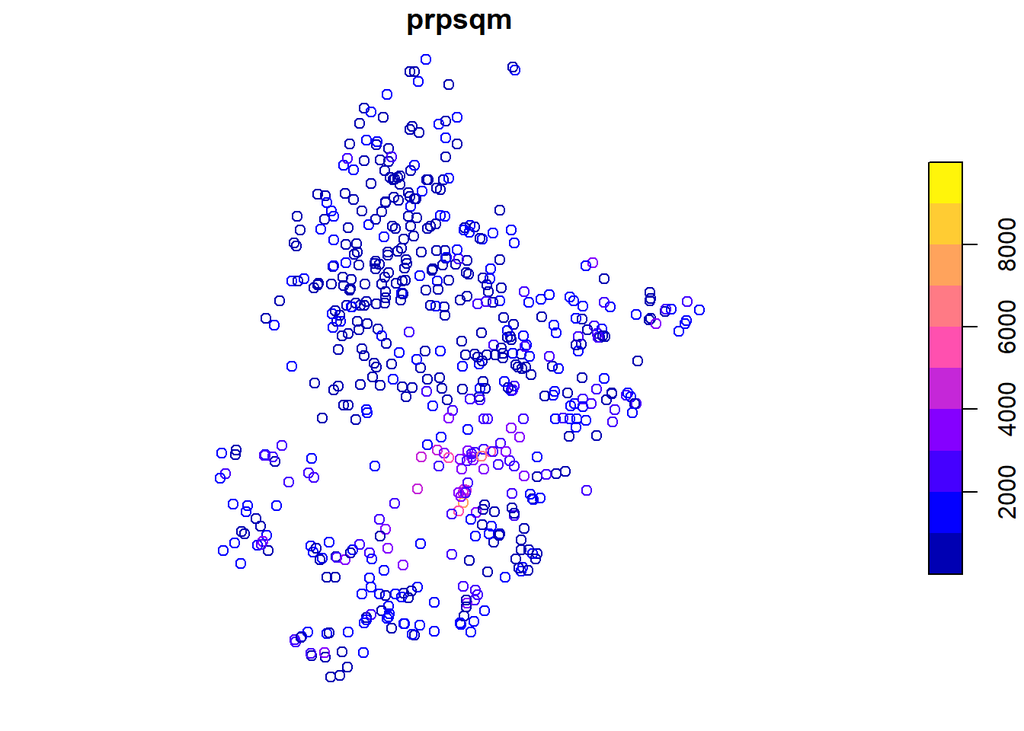

```r
plot(properties["prpsqm"])
```

The plot shows the distribution of properties with their color representing the price per square meter `prpsqm`. It’s hard to see a pattern from this chart, but it seems that most of the expensive properties are located towards the south.

Let’s plot our property locations on top of our district boundaries.

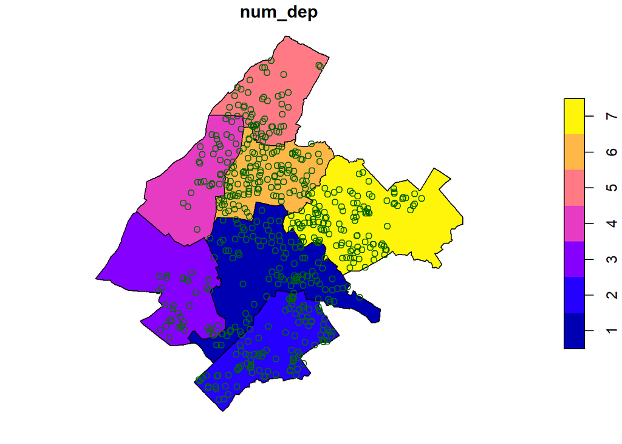

```r
plot(depmunic["num_dep"], reset = FALSE)
plot(properties["price"], add = TRUE, col = "darkgreen")
```

### Empirical Methods

Let’s try to put together a model to explain the price of properties in Athens using the hedonic pricing method. Our proposed specification will be:
$$P_{i} = \beta_0 + \beta_1 Size_{i} + \beta_2 Age_{i} + \beta_{3} Dist_{i} + \sum_{j=2}^{7} \gamma_{j} D_{ij} + \epsilon$$

where

- $P_{i}$ is the price (in euros) per square meter of apartment $i$,
- $Size_{i}$ is the size in square meters of apartment $i$,
- $Age_{i}$ is the age in years of apartment $i$,
- $Dist_{i}$ is the distance between apartment $i$ and the closest metro in meters,
- $D_{ij}$ are dummy variables indexing the districts $j$ for apartment $i$.

The dummy variables are included to account for district-specific characteristics, such as the number of museums, parks, area of greenspace, and other district specific factors that we don’t have data on.

Looking at our `properties` dataset, we see that we already have data on all of our regressors except district location of the apartments. We need to use what we learned about geospatial operations to assign a categorical variable indicating district location to each property.

Below we use the function `st_join()` to merge both datasets based on the intersection of the spatial elements, and pass the attribute `num_dep` (the district number) to the merged dataset.

```r
# find location districts for each property
merged_data <- st_join(properties, depmunic["num_dep"])
merged_data
```

```
Simple feature collection with 1000 features and 7 fields
Geometry type: POINT
Dimension:     XY
Bounding box:  xmin: 473914.2 ymin: 4200169 xmax: 480442.4 ymax: 4208576
Projected CRS: GGRS87 / Greek Grid
First 10 features:
       id size  price    prpsqm age dist_metro num_dep                 geometry
7836 7836   74  95000 1283.7838  47 623.874638       5 POINT (477144.1 4207786)
7238 7238   77 165000 2142.8571  10 509.471981       5 POINT (475649.5 4207224)
368   368   85  22000  258.8235  42 862.132569       2 POINT (477269.9 4201115)
938   938   85 225000 2647.0588  51   5.461505       1 POINT (476099.5 4202088)
6693 6693  102  50000  490.1961  37 312.350026       6 POINT (476260.6 4206307)
1953 1953  150 500000 3333.3333  37 485.829813       1 POINT (477290.7 4203248)
4950 4950   70 105000 1500.0000   1 892.577424       7 POINT (478399.6 4205376)
5037 5037   35   8500  242.8571  47 966.710340       6 POINT (476882.3 4205444)
7673 7673  100 160000 1600.0000  11 737.181066       5 POINT (476985.3 4207504)
6681 6681   71  31000  436.6197  57 296.557268       4 POINT (475656.2 4206286)
```

Notice that `st_join()` dropped the district boundaries. That is fine, since `num_dep` already indicates where each property is located. As a matter of fact, we don’t even need the points anymore. We only needed them to connect the apartments to their district! Let’s clean our data before running our model.

> **Note**: we should drop spatial objects with the function `st_drop_geometry()`, as opposed to `select()`.

```r
model_data <- merged_data %>%
                select(size, prpsqm, age, dist_metro, num_dep)%>%
                mutate(num_dep = as_factor(num_dep))%>%    # so that R understand that this is a categorical variable
                st_drop_geometry()
str(model_data)
```

```
'data.frame':   1000 obs. of  5 variables:
 $ size      : int  74 77 85 85 102 150 70 35 100 71 ...
 $ prpsqm    : num  1284 2143 259 2647 490 ...
 $ age       : num  47 10 42 51 37 37 1 47 11 57 ...
 $ dist_metro: num  623.87 509.47 862.13 5.46 312.35 ...
 $ num_dep   : Factor w/ 7 levels "1","2","3","4",..: 5 5 2 1 6 1 7 6 5 4 ...
```

### Results and Analysis

Now, we’re ready to run our hedonic pricing model. Let’s do that using `lm()`. R will automatically create dummy variables for each district.

```r
model1 <- lm(prpsqm ~ size + age + dist_metro + num_dep, data = model_data)
coeftest(model1, vcov = vcovHC)
```

```
t test of coefficients:

               Estimate  Std. Error  t value  Pr(>|t|)
(Intercept)  2.3522e+03  3.8638e+02   6.0879 1.634e-09 ***
size         4.2951e+00  4.1411e+00   1.0372  0.299911
age         -2.0071e+01  1.1886e+00 -16.8862 < 2.2e-16 ***
dist_metro  -1.4415e-01  5.1621e-02  -2.7925  0.005331 **
num_dep2    -3.3417e+02  1.5156e+02  -2.2049  0.027691 *
num_dep3    -4.8963e+02  1.5943e+02  -3.0712  0.002190 **
num_dep4    -1.0310e+03  1.2688e+02  -8.1253 1.322e-15 ***
num_dep5    -8.2216e+02  1.0289e+02  -7.9909 3.708e-15 ***
num_dep6    -9.1830e+02  1.0892e+02  -8.4312 < 2.2e-16 ***
num_dep7    -6.5270e+02  1.0433e+02  -6.2561 5.865e-10 ***
---
Signif. codes:  0 '***' 0.001 '**' 0.01 '*' 0.05 '.' 0.1 ' ' 1
```

The most significant factor contributing to the price of an apartment in Athens appears to be district location. Although age and distance to metro are statistically significant, their effects are quite small (as long as the property is not *super* old or *super* far from the closest metro). However, we do see a wide range of effects for district locations. Once we control for size, age, and distance from metro, the mere fact of being in district 4 decreases the price per square meter by over 1,000 euros! Maybe it’s the lack of greenspace that we have noted earlier…

Our model breaks down the price of an apartment as follows:

$$P_{i} = 2352 + 4.3 Size_{i} -20 Age_{i} -0.1 Dist_{i} + \sum_{i=2}^{7} \gamma_{i} D_{i} + e$$

In which the added effects for the dummies are:

- District 2: $-334$ euros
- District 3: $-490$ euros
- District 4: $-1031$ euros
- District 5: $-822$ euros
- District 6: $-918$ euros
- District 7: $-653$ euros

District 1 is the base case (i.e., when all dummies equal zero), and is the most accretive location to the price of a property. That makes sense, since District 1 is the historic center of Athens.

Now, let’s look at how well our model actually predicts the price per square meter of properties. This can shed light on the appropriateness of using hedonic pricing strategies for properties in Athens.

```r
summary(model1)$adj.r.squared
```

```
[1] 0.3568844
```

Our adjusted $R^2$ says that our model only explains ~35% of the variation in the price of properties in Athens. The cause of low predictive power could be an error of methodology (prices of properties in Athens might not be the sum of their component parts!), or a missing variable problem.

> **Think Deeper**: what component parts of properties might we be missing in our hedonic pricing model?